# Working with NIMBLE models

NIMBLE 2020 Virtual Workshop

NIMBLE Development Team

June 2020

# Overview

- Features of NIMBLE and NIMBLE’s model language useful for writing models
- Converting from WinBUGS/JAGS
- Models are graphs and why it matters
- Models are R objects that can be operated: calculation and simulation

# Alternative distribution parameterizations and named parameters

- BUGS/JAGS: Only `dnorm(mu, tau)` is supported, where `tau` is precision.
- NIMBLE: Alternative parameterizations and named parameters are supported:
  - `dnorm(mean = mu, sd = sigma)`
  - `dnorm(mean = mu, var = sigma_squared)`
  - `dnorm(mean = mu, tau = tau)` (tau = precision)
- Distributions with alternative parameterizations are listed in Table 5.2 of [User Manual Section 5.2.4](https://r-nimble.org/html_manual/cha-writing-models.html#subsec:dists-and-functions)
- Usage in the deer example.

```r
DEcode1partial <- nimbleCode({
  for(i in 1:2) {
    # Priors for intercepts and length coefficients for sex = 1,2
    sex.effect[i] ~ dnorm(0, sd = 1000)
    length.effect[i] ~ dnorm(0, sd = 1000)
  }

  # Priors for farm random effects and their standard deviation.
  farm.sd ~ dunif(0, 20)
  for(i in 1:num.farms) {
    farm.effect[i] ~ dnorm(0, sd = farm.sd)
  }
  # <snip>
  })
```

Note we placed the prior directly on the standard deviation parameter. In BUGS or JAGS you would need to do this:

```r
farm.sd ~ dunif(0, 20)
farm.prec <- 1/farm.sd^2
for(i in 1:num.farms) {
  farm.effect[i] ~ dnorm(0, farm.prec)
}
```

# What are constants? What are data?

### Constants are values needed to define model relationships

- Index ranges like `N`
- Constant indexing vectors
- Constants must be provided when creating a model with `nimbleModel`.

### Data represents a flag on the role a node plays in the model

- E.g., data nodes shouldn’t be sampled in MCMC.
- Data values can be changed.
- Data can be provided when calling `nimbleModel` or later.

### Providing data and constants together.

- Data and constants can be provided together **as `constants`**.
- It would be slightly easier for BUGS/JAGS users to call this “data”, but that would blur the concepts.
- NIMBLE will usually disambiguate data when it is provided as constants.

### What are covariates and other non-parameters/non-observations?

- Covariates/predictors are examples of values that are not parameters nor data in the sense of the likelihood.
- Covariates/predictors can be provided via `constants` if you don’t need to change them (often the case).
- Covariates/predictors can be provided via `data` or `inits` if you want to change them.
  - NIMBLE will not treat them as ‘data nodes’.

# Indexing

When values are grouped (particularly in irregular ways), we often have (potentially complicated) indexing.

Here `sex` and `farm.ids` are vectors of membership indexes that are known in advance. Make sure to provide them in `constants` to avoid unnecessary computation (more later).

```r
for(i in 1:num.animals) {
  logit(disease.probability[i]) <-
    sex.effect[ sex[i] ] +
    length.effect[ sex[i] ] * cLength[i] +
    farm.effect[ farm.ids[i] ]
  Ecervi.01[i] ~ dbern(disease.probability[i])
}
```

Particularly in ecological models, indexing can get very complicated.

The farm grouping above is ‘ragged’ (as is the sex assignment). If the number of observations per farm were constant (‘regular’/‘rectangular’), we could have something like this (ignoring sex and length):

```r
for(j in 1:num.farms)
  for(i in 1:num.animals.per.farm) {
    logit(disease.probability[j, i]) <- farm.effect[j]
    Ecervi.01[j, i] ~ dbern(disease.probability[j, i])
  }
```

# Models are graphs

- Ecologists and many statisticians speak of “hierarchical models”.
- Computer scientists and others sometimes speak of “graphical models”.
- A hierarchical model is typically a directed acyclic graph (DAG).

# NIMBLE models as objects

When you create a NIMBLE model, it is an object in R.

You can:

- Get or set parameter or data values.
- Determine graph relationships.
- Calculate log probabilities.
- Simulate (draw) from distributions.
- More.

# Linear regression example

Let’s use a really simple model:

- Linear regression with 4 data points.

```r
set.seed(1)
code <- nimbleCode({
  intercept ~ dnorm(0, sd = 1000)
  slope ~ dnorm(0, sd = 1000)
  sigma ~ dunif(0, 100)
  for(i in 1:4) {
    predicted.y[i] <- intercept + slope * x[i]
    y[i] ~ dnorm(predicted.y[i], sd = sigma)
  }
})
model <- nimbleModel(code,
                     data = list(y = rnorm(4)),
                     inits = list(intercept = 0.5,
                                  slope = 0.2,
                                  sigma = 1,
                                  x = c(0.1, 0.2, 0.3, 0.4)))
```

```
## defining model...
```

```
## building model...
```

```
## setting data and initial values...
```

```
## running calculate on model (any error reports that follow may simply reflect missing values in model variables) ...
## checking model sizes and dimensions...
## model building finished.
```

`x` values are neither observations (‘data’) nor parameters. `x` can also be provided in `constants` (this is generally best, unless you plan to change `x`) or in `data` (for consistency with WinBUGS/JAGS).

# Draw the graph:

This was done with package `igraph`.

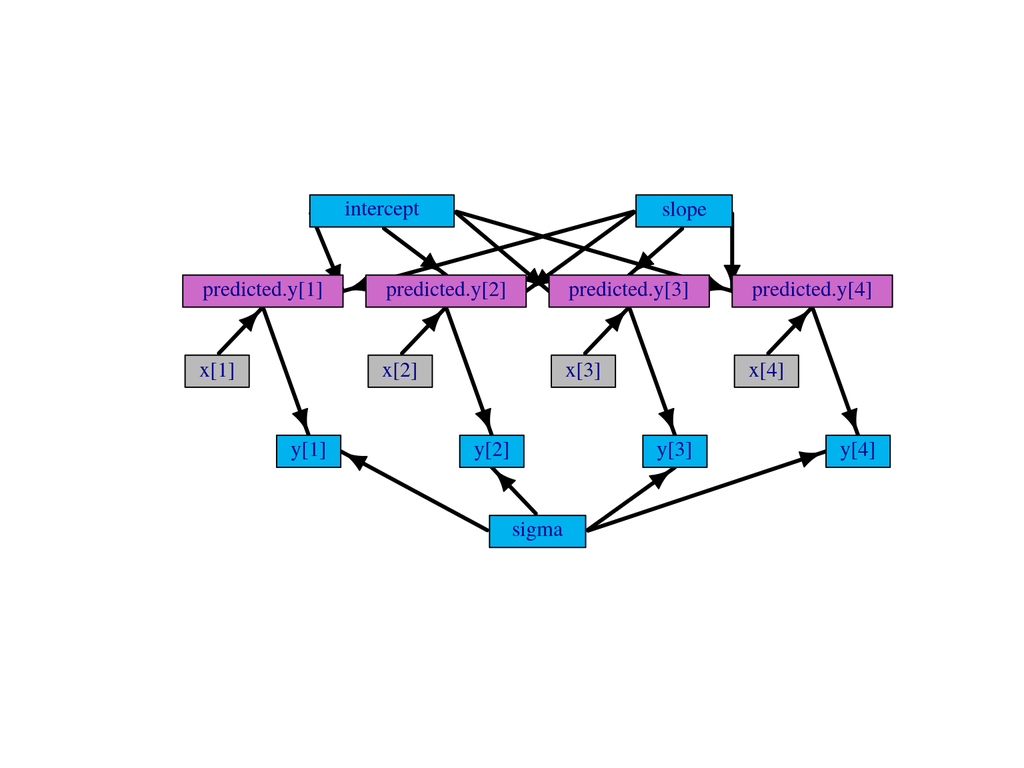

- Think of each line of BUGS language code as declaring one or mode *nodes*.

# Get and set values

This is done in natural R syntax.

```r
model$sigma
```

```
## [1] 1
```

```r
model$x
```

```
## [1] 0.1 0.2 0.3 0.4
```

```r
model$x[3] <- 0.6
model$x
```

```
## [1] 0.1 0.2 0.6 0.4
```

This can be done with a compiled model too.

# You can even get and set data values

```r
model$y
```

```
## [1] -0.6264538  0.1836433 -0.8356286  1.5952808
```

```r
model$y[1] <- 0.8
model$y
```

```
## [1]  0.8000000  0.1836433 -0.8356286  1.5952808
```

Why would this be useful?

# Get names of nodes in the graph

```r
model$getNodeNames()
```

```
##  [1] "intercept"      "slope"          "sigma"          "predicted.y[1]"
##  [5] "predicted.y[2]" "predicted.y[3]" "predicted.y[4]" "y[1]"
##  [9] "y[2]"           "y[3]"           "y[4]"
```

## Get types of nodes

```r
model$getNodeNames(dataOnly = TRUE)
```

```
## [1] "y[1]" "y[2]" "y[3]" "y[4]"
```

```r
model$getNodeNames(determOnly = TRUE)
```

```
## [1] "predicted.y[1]" "predicted.y[2]" "predicted.y[3]" "predicted.y[4]"
```

```r
model$isData('y')
```

```
## [1] TRUE TRUE TRUE TRUE
```

```r
model$isData('x')
```

```
## [1] FALSE FALSE FALSE FALSE
```

# Get node relationships

```r
model$getDependencies("x[2]")
```

```
## [1] "predicted.y[2]" "y[2]"
```

```r
model$getDependencies("sigma")
```

```
## [1] "sigma" "y[1]"  "y[2]"  "y[3]"  "y[4]"
```

```r
model$getDependencies("slope")
```

```
## [1] "slope"          "predicted.y[1]" "predicted.y[2]" "predicted.y[3]"
## [5] "predicted.y[4]" "y[1]"           "y[2]"           "y[3]"
## [9] "y[4]"
```

# Why do node relationships matter?

For typical MCMC samplers, `model$getDependencies('slope')` returns the nodes that need to be calculated when sampling `slope`.

Results from `model$getDependencies` are in *topologically sorted* order:

- If you calculate them in order, you’ll get correct results.
- E.g `predicted.y[2]` comes before `y[2]`.

## Why provide indexes as constants?

Recall the likelihood component of the Deer model:

```r
for(i in 1:num.animals) {
  logit(disease.probability[i]) <-
    sex.effect[ sex[i] ] +
    length.effect[ sex[i] ] * Length[i] +
    farm.effect[ farm.ids[i] ]
  Ecervi.01[i] ~ dbern(disease.probability[i])
```

Let’s consider passing `farm.ids` either in `constants` or in `data`.

```r
DEconstants <- list(num.farms = 24,
                    num.animals = 826,
                    cLength = DeerEcervi$cLength,
                    sex = DeerEcervi$Sex,
                    farm.ids = DeerEcervi$farm.ids)
DEdata <- list(Ecervi.01 = DeerEcervi$Ecervi.01)

m_light <- nimbleModel(DEcode1, constants = DEconstants)
```

```
## defining model...
```

```
## building model...
```

```
## running calculate on model (any error reports that follow may simply reflect missing values in model variables) ...
## checking model sizes and dimensions... This model is not fully initialized. This is not an error. To see which variables are not initialized, use model$initializeInfo(). For more information on model initialization, see help(modelInitialization).
## model building finished.
```

```r
DEconstants <- list(num.farms = 24,
                    num.animals = 826,
                    cLength = DeerEcervi$cLength)
DEdata <- list(Ecervi.01 = DeerEcervi$Ecervi.01,
                    sex = DeerEcervi$Sex,
                    farm.ids = DeerEcervi$farm.ids)
m_heavy <-  nimbleModel(DEcode1, data = DEdata, constants = DEconstants)
```

```
## defining model...
```

```
## building model...
## setting data and initial values...
## running calculate on model (any error reports that follow may simply reflect missing values in model variables) ...
## checking model sizes and dimensions... This model is not fully initialized. This is not an error. To see which variables are not initialized, use model$initializeInfo(). For more information on model initialization, see help(modelInitialization).
## model building finished.
```

Now let’s look at the dependency (graph) structure.

```r
m_light$getDependencies('farm.effect[1]')
```

```
##  [1] "farm.effect[1]"          "disease.probability[1]"
##  [3] "disease.probability[2]"  "disease.probability[3]"
##  [5] "disease.probability[4]"  "disease.probability[5]"
##  [7] "disease.probability[6]"  "disease.probability[7]"
##  [9] "disease.probability[8]"  "disease.probability[9]"
## [11] "disease.probability[10]" "disease.probability[11]"
## [13] "disease.probability[12]" "disease.probability[13]"
## [15] "disease.probability[14]" "disease.probability[15]"
## [17] "Ecervi.01[1]"            "Ecervi.01[2]"
## [19] "Ecervi.01[3]"            "Ecervi.01[4]"
## [21] "Ecervi.01[5]"            "Ecervi.01[6]"
## [23] "Ecervi.01[7]"            "Ecervi.01[8]"
## [25] "Ecervi.01[9]"            "Ecervi.01[10]"
## [27] "Ecervi.01[11]"           "Ecervi.01[12]"
## [29] "Ecervi.01[13]"           "Ecervi.01[14]"
## [31] "Ecervi.01[15]"
```

```r
too_many_deps <- m_heavy$getDependencies('farm.effect[1]')
length(too_many_deps)
```

```
## [1] 1653
```

```r
head(too_many_deps)
```

```
## [1] "farm.effect[1]"         "disease.probability[1]"
## [3] "disease.probability[2]" "disease.probability[3]"
## [5] "disease.probability[4]" "disease.probability[5]"
```

If `farm.ids` (and `sex`) are not known to NIMBLE to be constants, then all the observations could potentially depend on any element of `farm.effects`, `sex.effect`, `length.effect`.

Consider what would happen in a Metropolis-Hastings sampler for `farm.effect[1]` in the ‘heavy’ model.

# Converting from JAGS/BUGS to NIMBLE

See our [guide online](https://r-nimble.org/quick-guide-for-converting-from-jags-or-bugs-to-nimble).

How NIMBLE extends BUGS

- Alternative distribution parameterizations (like R) [seen above].
- Named parameters (like R) [seen above].
- Distinction between `constants` and `data` [seen above].
- Vectorized math and linear algebra [more below].
- Definition-time if-then-else (multiple model variants from the same code) [more below].
- User-defined functions and distributions [later today].

And a limitation of NIMBLE - NIMBLE is stricter about requiring dimensions for vectors, matrices, and arrays [more below].

# More explicit need to provide dimensions

- Square brackets must always be provided to indicate number of dimensions
  - If `x` is 2-dimensional, use `x[,] %*% beta[]`, not `x %*% beta`
- Sometimes NIMBLE is not as smart as BUGS/JAGS at determining dimensions. There are two solutions:
  - Give dimensions explicity: `x[1:n, 1:m]`, OR
  - Provide a `dimensions` argument to `nimbleModel`. Example: `dimensions = list(x = c(n, m))`.

# Be careful about scalar vs. vector vs. matrix vs. array

This will not work:

```r
x[1:5] <- (A[1:5, 1:5] %*% b[1:5] + c[1:5])
```

The problem is that the right-hand-side returns a matrix, so we can’t assign it to a vector.

This will work:

```r
x[1:5] <- (A[1:5, 1:5] %*% b[1:5] + c[1:5])[,1]
```

# Definition-time if-then-else

If you wish to define multiple alternative models in one set of code, you can use if-then-else statements. These will be evaluated based on variables in the R environment when the model is defined. For example:

```r
code <- nimbleCode({
  sigma ~ dunif(0, 10)
  beta0 ~ dnorm(0, sd = 1000)
  beta1 ~ dnorm(0, sd = 1000)
  if(INCLUDE_X2) {
    beta2 ~ dnorm(0, sd = 1000)
  }
  for(i in 1:10) {
    if(INCLUDE_X2) {
      y[i] ~ dnorm(beta0 + beta1 * x1[i] + beta2 * x2[i], sd = sigma)
    } else {
      y[i] ~ dnorm(beta0 + beta1 * x1[i], sd = sigma)
    }
  }
})

INCLUDE_X2 <- FALSE
m1 <- nimbleModel(code)
INCLUDE_X2 <- TRUE
m2 <- nimbleModel(code)
```

m2 has `beta2` while m1 does not.

# Nodes vs. variables

In NIMBLE:

- A variable is an object that may contain multiple nodes.
  - `y` is a variable.
- A node is a part of a variable declared in one line of BUGS code.
  - `y[1]` … `y[4]` are scalar nodes.

# How vectorizing changes nodes

```r
code2 <- nimbleCode({
  intercept ~ dnorm(0, sd = 1000)
  slope ~ dnorm(0, sd = 1000)
  sigma ~ dunif(0, 100)
  predicted.y[1:4] <- intercept + slope * x[1:4] # vectorized node
  for(i in 1:4) {
    # predicted.y[i] <- intercept + slope * x[i] # scalar nodes (earlier model version)
    y[i] ~ dnorm(predicted.y[i], sd = sigma)
  }
})

model2 <- nimbleModel(code2,
                      data = list(y = rnorm(4)),
                      inits = list(intercept = 0.5,
                                   slope = 0.2,
                                   sigma = 1,
                                   x = c(0.1, 0.2, 0.3, 0.4)))
```

```
## defining model...
```

```
## building model...
```

```
## setting data and initial values...
```

```
## running calculate on model (any error reports that follow may simply reflect missing values in model variables) ...
## checking model sizes and dimensions...
## model building finished.
```

## Look at nodes in the vectorized model:

```r
model2$getNodeNames()
```

```
## [1] "intercept"        "slope"            "sigma"
## [4] "predicted.y[1:4]" "y[1]"             "y[2]"
## [7] "y[3]"             "y[4]"
```

```r
model2$getDependencies('x[2]')
```

```
## [1] "predicted.y[1:4]" "y[1]"             "y[2]"
## [4] "y[3]"             "y[4]"
```

In this case, if `x[2]` had a prior and was being sampled in MCMC, it would be inefficient to calculate all of `y[1]`, `y[2]`, `y[3]`, `y[4]`.

# Log probability calculations

```r
model$calculate('y[1:4]')
```

```
## [1] -5.267736
```

This is the sum of log probabilities of all stochastic nodes in the calculation.

Deterministic nodes have their values calculated but contribute 0 to the log probability.

```r
model$getDependencies('intercept')
```

```
## [1] "intercept"      "predicted.y[1]" "predicted.y[2]" "predicted.y[3]"
## [5] "predicted.y[4]" "y[1]"           "y[2]"           "y[3]"
## [9] "y[4]"
```

```r
model$calculate(model$getDependencies('intercept'))
```

```
## [1] -13.17997
```

In this case, this is the sum of log probabilities from almost the entire model.

Only the priors for `slope` and `sigma` are not included.

# Simulating from the model

In this model, there are no random effects. The only stochastic nodes are data or parameters with priors.

```r
model$sigma
```

```
## [1] 1
```

```r
model$simulate('sigma')
model$sigma
```

```
## [1] 71.76185
```

Data values are protected from simulation unless you are sure.

(The following is not good model-generic programming. See below.)

```r
model$y
```

```
## [1]  0.8000000  0.1836433 -0.8356286  1.5952808
```

```r
model$simulate('y') ## Will not over-write data nodes
```

```r
model$y
```

```
## [1]  0.8000000  0.1836433 -0.8356286  1.5952808
```

```r
model$simulate('y', includeData = TRUE) ## will over-write data nodes
model$y
```

```
## [1] 173.08238  55.33688 -56.71838 -81.77799
```

# Understanding *lifted nodes*

Consider the following version of our linear regression model.

There is no `predicted.y[i]`. The expression from that is directly in the `dnorm` for `y[i]`. Also, we now use the variance instead of the standard deviation in the likelihood.

```r
code3 <- nimbleCode({
  intercept ~ dnorm(0, sd = 1000)
  slope ~ dnorm(0, sd = 1000)
  sigma2 ~ dinvgamma(1, 1)  # this sort of prior not generally recommended
  for(i in 1:4) {
    y[i] ~ dnorm(intercept + slope * x[i], var = sigma2)
  }
})
model3 <- nimbleModel(code3,
                      data = list(y = rnorm(4)),
                      inits = list(intercept = 0.5,
                                   slope = 0.2,
                                   sigma2 = 1,
                                   x = c(0.1, 0.2, 0.3, 0.4)))
```

```
## defining model...
```

```
## building model...
```

```
## setting data and initial values...
```

```
## running calculate on model (any error reports that follow may simply reflect missing values in model variables) ...
## checking model sizes and dimensions...
## model building finished.
```

## Look at the nodes

```r
model3$getNodeNames()
```

```
##  [1] "intercept"
##  [2] "slope"
##  [3] "sigma2"
##  [4] "lifted_sqrt_oPsigma2_cP"
##  [5] "lifted_intercept_plus_slope_times_x_oBi_cB_L5[1]"
##  [6] "lifted_intercept_plus_slope_times_x_oBi_cB_L5[2]"
##  [7] "lifted_intercept_plus_slope_times_x_oBi_cB_L5[3]"
##  [8] "lifted_intercept_plus_slope_times_x_oBi_cB_L5[4]"
##  [9] "y[1]"
## [10] "y[2]"
## [11] "y[3]"
## [12] "y[4]"
```

NIMBLE has created nodes in the role of `predicted.y[i]` and `sigma`.

These are called *lifted nodes*. They are created by “lifting” an expression out of a parameter for a distribution and creating a deterministic node for that expression.

Why does NIMBLE do that?

# Model-generic programming: concrete example

If we change `sigma2` and then directly try to work with `y`, we’ll cause (silent errors) because the lifted standard deviation has not been updated.

```r
model3$sigma2 <- 100
model3$lifted_sqrt_oPsigma2_cP
```

```
## [1] 1
```

```r
model3$simulate('y', includeData = TRUE)
summary(model3$y)
```

```
##      Min.   1st Qu.    Median      Mean   3rd Qu.      Max.
## -0.677538 -0.448325 -0.008094  0.070489  0.510720  0.975683
```

```r
depNodes <- model3$getDependencies('sigma2', self = FALSE)
depNodes
```

```
## [1] "lifted_sqrt_oPsigma2_cP" "y[1]"
## [3] "y[2]"                    "y[3]"
## [5] "y[4]"
```

```r
model3$simulate(depNodes, includeData = TRUE)
model3$lifted_sqrt_oPsigma2_cP
```

```
## [1] 10
```

```r
summary(model3$y)
```

```
##     Min.  1st Qu.   Median     Mean  3rd Qu.     Max.
## 0.008932 1.407256 3.083660 3.694537 5.370941 8.601895
```

# Model-generic programming

Say we want a function that simulates all parts of a model that depend on some input nodes and then returns the corresponding summed log probability. I will call this part of the model “downstream”.

```r
simulate_downstream <- function(model, nodes) {
  downstream_nodes <- model$getDependencies(nodes, downstream = TRUE)
  model$simulate( downstream_nodes, includeData = TRUE )
  logProb <- model$calculate( downstream_nodes )
  logProb
}
```

Notice that this function will work with *any* model and *any* set of input nodes.

```r
model$y
```

```
## [1] 173.08238  55.33688 -56.71838 -81.77799
```

```r
simulate_downstream(model, 'sigma2')
```

```
## [1] 0
```

```r
model$y
```

```
## [1] 173.08238  55.33688 -56.71838 -81.77799
```

In this case, the model doesn’t have much hierarchical structure.

# Always use graph structure in model-generic programming

You may not know where there are lifted nodes.

Always determine what to `calculate` or `simulate` from `getDependencies` or other such tools.

# Exercises

1. Please run through the code from this module and use the commands discussed to understand the nodes and dependency structure of the Deer example.
2. Write code to fix the hyperparameters of the Deer example and given those fixed values, generate random farm effects and new observations, as would be needed for a simulation study:

```r
model$farm.sd <- 1
model$sex.effect <- c(1.5, 2.5)
model$length.effect <- c(0.3, 0.5)
# explore the arguments for `getDependencies` and `simulate`
deps <- model$getDependencies('???')
model$simulate(???)
```